# SARIMA Model

Vaibhavnath Jha

24 July 2020

```r
library("forecast"); library("ggplot2"); library("readxl"); library(tseries); theme_set(theme_light())
sales_data <- read_excel("GER_retail_sales.xlsx")
```

```r
library(anomalize)
```

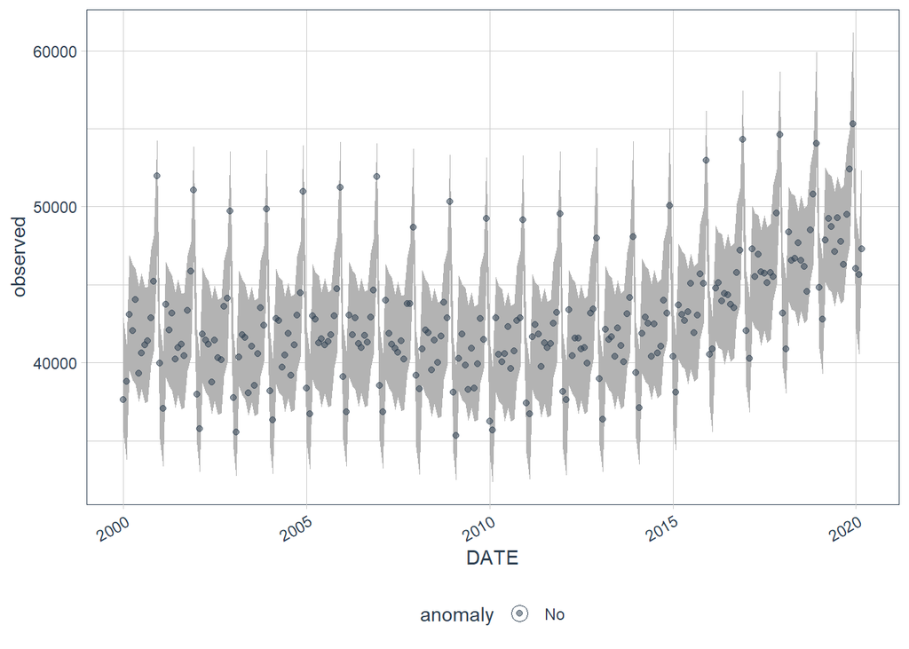

```r
decomposed = time_decompose(data = sales_data,target = SALES, message = FALSE)
anomaly = anomalize (data = decomposed,target = remainder)
series_recomposed = time_recompose(data = anomaly)
plot_anomalies(data = series_recomposed,time_recomposed = TRUE, ncol = 3, alpha_dots = 0.5)
```

No anomalies/ outliers were detected. We can proceed with the original data.

```r
sales_ts <- ts(sales_data[,2],start = 2000,frequency = 12)
sales_train <- window(sales_ts, start=c(2000,1),end=c(2015,12))
```

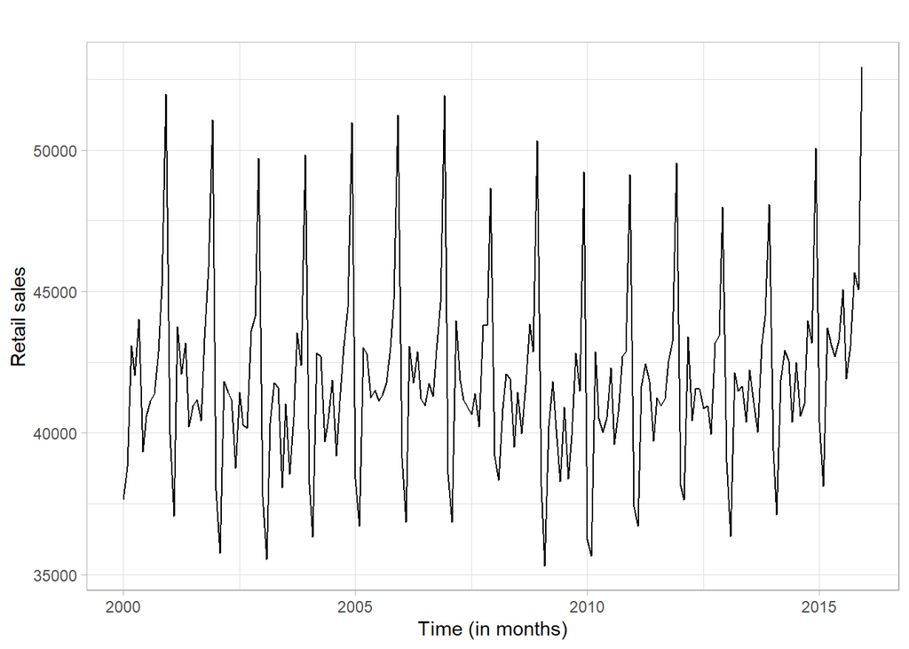

```r
autoplot(sales_train) + xlab("Time (in months)") + ylab("Retail sales")
```

#### The plot straight away shows that there is presence of seasonality and no perticular trend is present. The mean is centered around 42500 and the series is definitely non-stationary

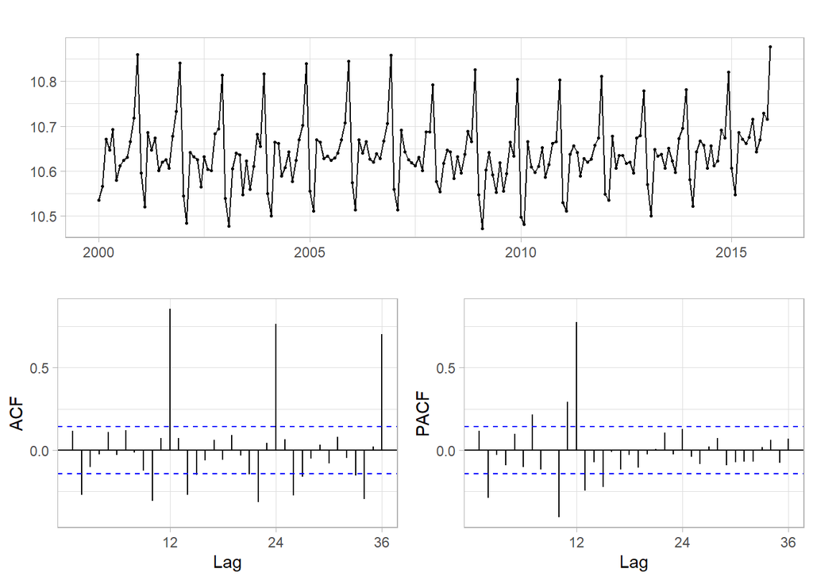

```r
transformed_sales <- log(sales_train)
ggtsdisplay(transformed_sales)
```

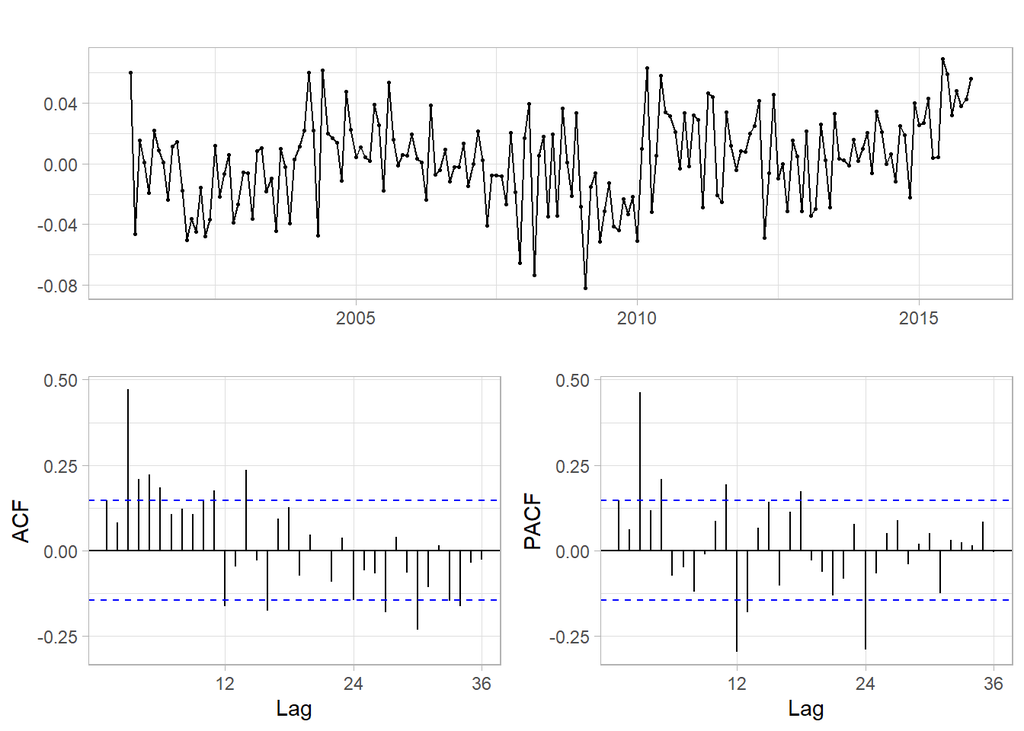

```r
diff_sales <- diff(transformed_sales,12)
ggtsdisplay(diff_sales)
```

```r
ndiffs(diff_sales)
```

```
## [1] 1
```

The seasonal differenced series still appear to be non-stationary, and *nidffs* function also tells us to differentiate once more.

```r
diff_sales_again <- diff(diff_sales, 1)
adf.test(diff_sales_again)
```

```
##
##  Augmented Dickey-Fuller Test
##
## data:  diff_sales_again
## Dickey-Fuller = -7.4782, Lag order = 5, p-value = 0.01
## alternative hypothesis: stationary
```

Null Hypothesis is rejected. We can say that now our series is Stationary.We can start our analysis now.

- As of now, I(D) = 1 and I(d) = 1

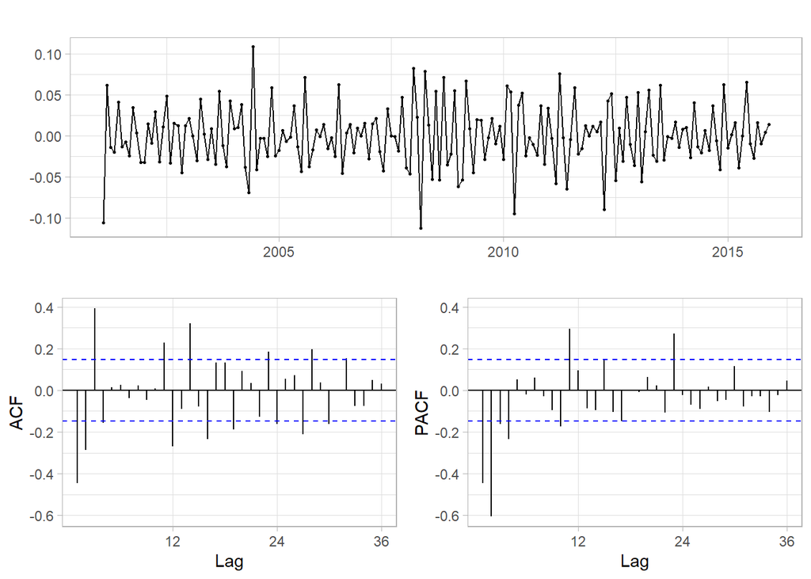

```r
ggtsdisplay(diff_sales_again)
```

- Significant non-seasonal lags at Lag 1 and 2 in ACF suggests an *MA(2)* model
- Significant seasonal lag at Lag 12 suggests an *MA(1)* seasonal model

We will try to fit an *ARIMA(0,1,2)(0,1,1)[12]* model

```r
fitArima_012_011 <- Arima(sales_train, order = c(0,1,2), seasonal = c(0,1,1), lambda = 0)
summary(fitArima_012_011)
```

```
## Series: sales_train
## ARIMA(0,1,2)(0,1,1)[12]
## Box Cox transformation: lambda= 0
##
## Coefficients:
##           ma1     ma2     sma1
##       -1.0732  0.3158  -0.7072
## s.e.   0.0722  0.0748   0.0663
##
## sigma^2 estimated as 0.0005322:  log likelihood=418.82
## AIC=-829.65   AICc=-829.42   BIC=-816.9
##
## Training set error measures:
##                    ME     RMSE      MAE        MPE     MAPE     MASE       ACF1
## Training set 35.55084 915.1288 719.2133 0.08012758 1.726788 0.743759 0.04857844
```

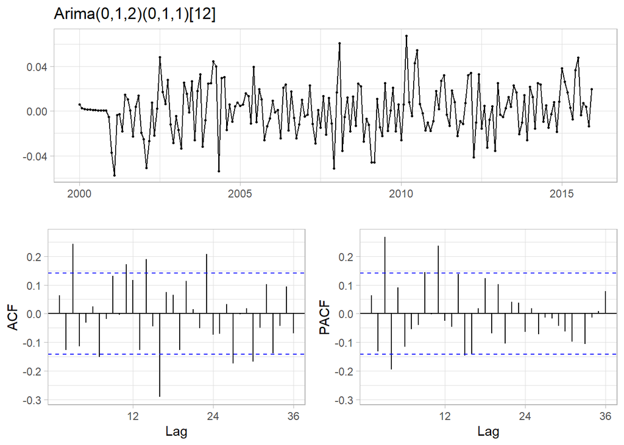

```r
residuals(object = fitArima_012_011) %>% ggtsdisplay(main = "Arima(0,1,2)(0,1,1)[12]", theme = theme_light())
```

We see that there are significant spikes in ACF and PACF indicating that there are some more terms to be included in the model. Specifically Lag 3 is significant in both plots. PACF also has a significant lag at 4.

Next we’ll try to fit *ARIMA(1,1,2)(0,1,1)[12]*, as from ACF there’s no other susbstantial information.

```r
fitArima_112_011 <- Arima(sales_train, order = c(1,1,2), seasonal = c(0,1,1), lambda = 0)
summary(fitArima_112_011)
```

```
## Series: sales_train
## ARIMA(1,1,2)(0,1,1)[12]
## Box Cox transformation: lambda= 0
##
## Coefficients:
##          ar1      ma1     ma2     sma1
##       0.1219  -1.1719  0.3909  -0.7070
## s.e.  0.1844   0.1616  0.1278   0.0671
##
## sigma^2 estimated as 0.0005338:  log likelihood=419.06
## AIC=-828.13   AICc=-827.78   BIC=-812.19
##
## Training set error measures:
##                    ME     RMSE      MAE     MPE     MAPE      MASE       ACF1
## Training set 34.00523 913.7639 719.2714 0.07571 1.727659 0.7438191 0.03669854
```

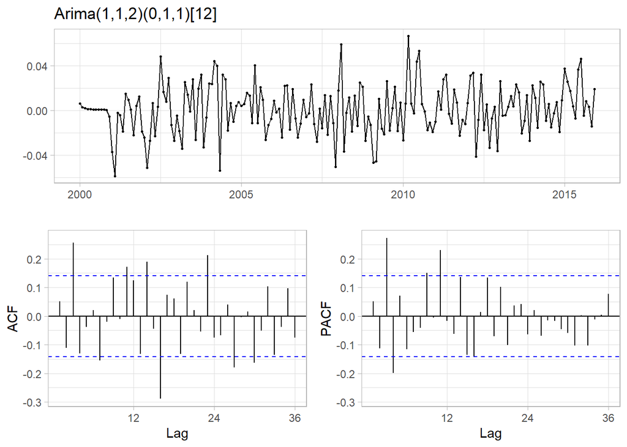

```r
residuals(fitArima_112_011) %>% ggtsdisplay(main = "Arima(1,1,2)(0,1,1)[12]", theme = theme_light())
```

- Marginal worse IC values than last model
- PACF has two significant lags at 3 and 4, Try fitting *ARIMA(2,1,2)(0,1,1)[12]* model
- No significant information from ACF

```r
fitArima_212_011 <- Arima(sales_train, order = c(2,1,2), seasonal = c(0,1,1), lambda = 0, include.constant = TRUE)
summary(fitArima_212_011)
```

```
## Series: sales_train
## ARIMA(2,1,2)(0,1,1)[12]
## Box Cox transformation: lambda= 0
##
## Coefficients:
##           ar1      ar2     ma1      ma2     sma1
##       -0.9352  -0.5169  0.0038  -0.3948  -0.6838
## s.e.   0.1162   0.0780  0.1292   0.1239   0.0672
##
## sigma^2 estimated as 0.0004723:  log likelihood=430.91
## AIC=-849.83   AICc=-849.34   BIC=-830.7
##
## Training set error measures:
##                    ME     RMSE      MAE        MPE     MAPE      MASE
## Training set 32.63036 850.3358 656.8036 0.07080255 1.584083 0.6792194
##                    ACF1
## Training set 0.02353749
```

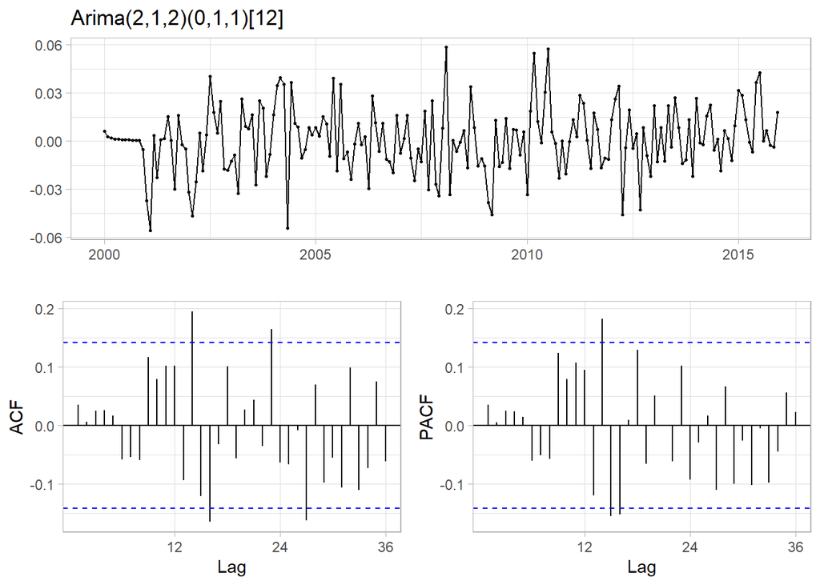

```r
residuals(fitArima_212_011) %>% ggtsdisplay(main = "Arima(2,1,2)(0,1,1)[12]", theme = theme_light())
```

- Better ICs obtained than all models tested previously.
- There are still some significant spikes, could try fitting *ARIMA(3,1,2)(0,1,1)[12]* or *ARIMA(2,1,3)(0,1,1)[12]*

```r
fitArima_312_011 <- Arima(sales_train, order = c(3,1,2), seasonal = c(0,1,1), lambda = 0)
summary(fitArima_312_011)
```

```
## Series: sales_train
## ARIMA(3,1,2)(0,1,1)[12]
## Box Cox transformation: lambda= 0
##
## Coefficients:
##           ar1      ar2      ar3     ma1      ma2     sma1
##       -1.0809  -0.6393  -0.1030  0.1413  -0.4153  -0.6729
## s.e.   0.2514   0.2337   0.1782  0.2387   0.1015   0.0711
##
## sigma^2 estimated as 0.0004751:  log likelihood=431.05
## AIC=-848.11   AICc=-847.45   BIC=-825.8
##
## Training set error measures:
##                    ME     RMSE      MAE        MPE    MAPE      MASE       ACF1
## Training set 30.22619 850.4559 659.3693 0.06517316 1.58995 0.6818727 0.03196716
```

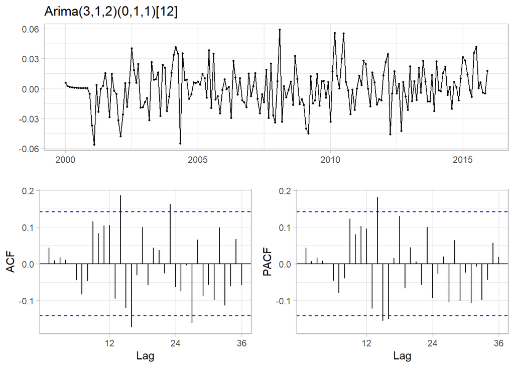

```r
residuals(fitArima_312_011) %>% ggtsdisplay(main = "Arima(3,1,2)(0,1,1)[12]", theme = theme_light())
```

```r
fitArima_213_011 <- Arima(sales_train, order = c(2,1,3), seasonal = c(0,1,1), lambda = 0)
summary(fitArima_213_011)
```

```
## Series: sales_train
## ARIMA(2,1,3)(0,1,1)[12]
## Box Cox transformation: lambda= 0
##
## Coefficients:
##           ar1      ar2      ma1      ma2     ma3     sma1
##       -0.8877  -0.4564  -0.0509  -0.4179  0.0742  -0.6737
## s.e.   0.1506   0.1462   0.1627   0.1159  0.1457   0.0713
##
## sigma^2 estimated as 0.0004752:  log likelihood=431.04
## AIC=-848.07   AICc=-847.42   BIC=-825.76
##
## Training set error measures:
##                   ME     RMSE     MAE        MPE    MAPE      MASE       ACF1
## Training set 30.0438 850.5609 659.196 0.06487023 1.58945 0.6816934 0.03069566
```

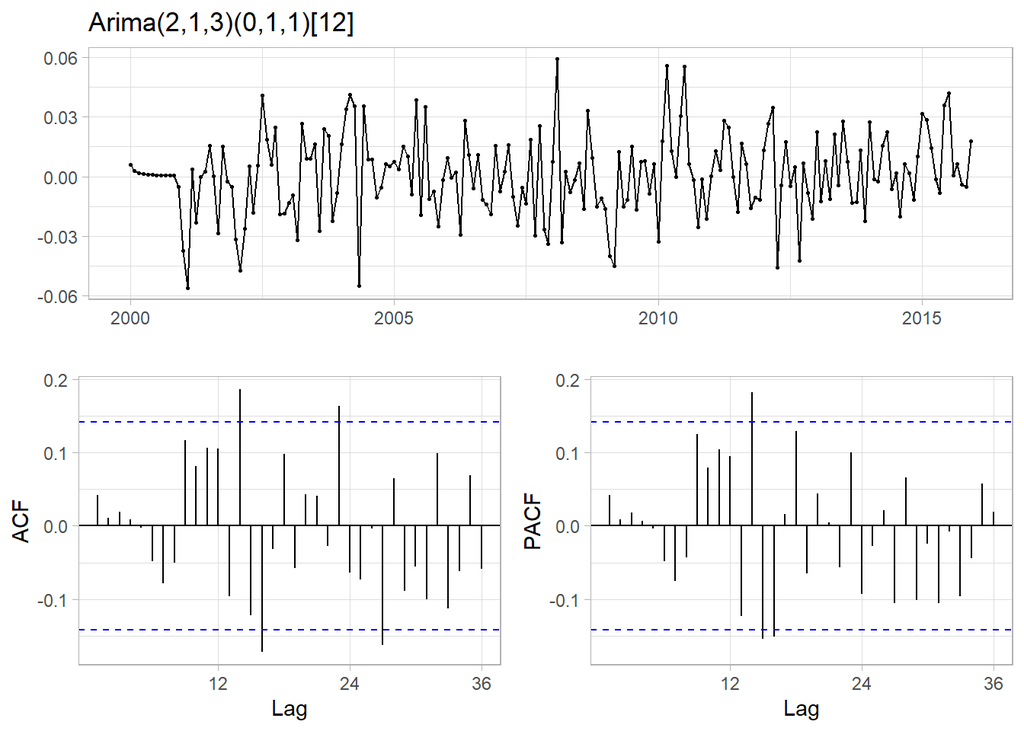

```r
residuals(fitArima_213_011) %>% ggtsdisplay(main = "Arima(2,1,3)(0,1,1)[12]", theme = theme_light())
```

Both Models *ARIMA(3,1,2)(0,1,1)[12]* and *ARIMA(2,1,3)(0,1,1)[12]* produce marginally worse ICs than previously fitted model.

##### Thus, *ARIMA(2,1,2)(0,1,1)[12]* model is the best fit for the data

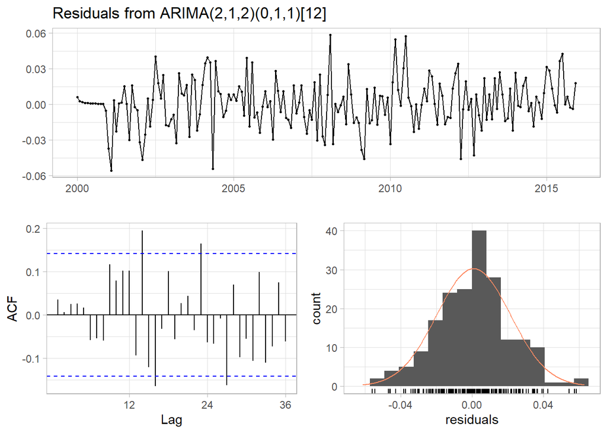

```
##
##  Ljung-Box test
##
## data:  Residuals from ARIMA(2,1,2)(0,1,1)[12]
## Q* = 40.108, df = 19, p-value = 0.003168
##
## Model df: 5.   Total lags used: 24
```

```r
checkresiduals(fitArima_212_011)
```

Checking Rolling Forecasts for the model on the hold-out data

```r
forecastarima <- function(x, h){forecast(x, model=fitArima_212_011, h=h)}
sales_ts %>% tsCV(forecastfunction = forecastarima, h = 1) %>% window (start=2016) -> testfce
mean(testfce^2, na.rm = TRUE) %>% sqrt() -> testrmse
print(testrmse)
```

```
## [1] 1081.64
```

```r
forecastSnaive <- function(x, h){forecast(snaive(x), h=h)}
sales_ts %>% tsCV(forecastfunction = forecastSnaive, h = 1) %>% window (start=2016) -> testfce
mean(testfce^2, na.rm = TRUE) %>% sqrt() -> testrmse
print(testrmse)
```

```
## [1] 1604.916
```

```r
forecastnaive <- function(x, h){forecast(naive(x), h=h)}
sales_ts %>% tsCV(forecastfunction = forecastnaive, h = 1) %>% window (start=2016) -> testfce
mean(testfce^2, na.rm = TRUE) %>% sqrt() -> testrmse
print(testrmse)
```

```
## [1] 4008.185
```

Since, *RMSE(ARIMA_model) < {RMSE(Naive_model), RMSE (Snaive_model)}* : It is evidence that ARIMA model is a good fit for the data.

##### Forecasting from April 2020 until December 2020

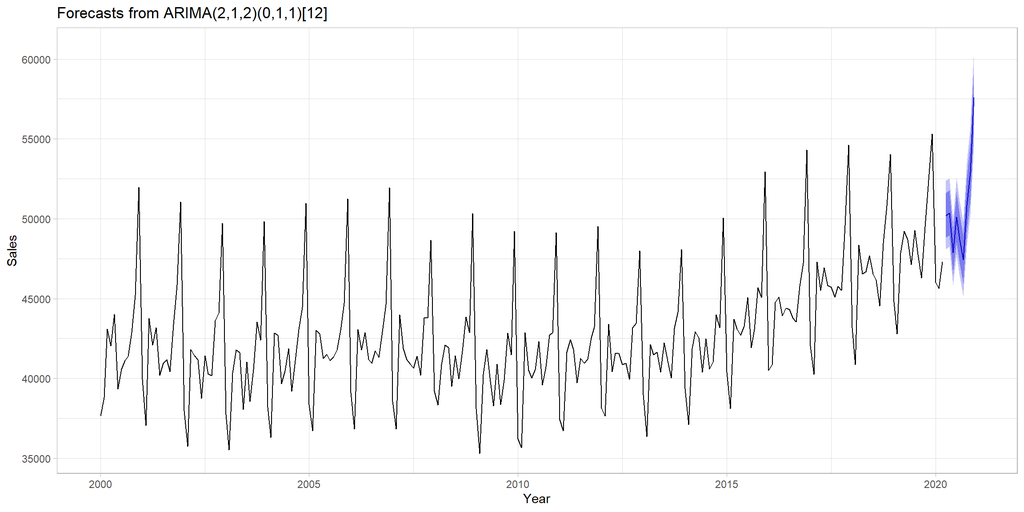

```r
sales_ts %>% Arima(order=c(2,1,2),seasonal = c(0,1,1),lambda = 0) %>% forecast(h=9) %>% autoplot() + xlab('Year') + ylab('Sales')
```